# Cyclistic Trips Data Analysis

Bernice Akinwande

2022-10-14

# Cyclisytic Trips Data

## Cyclistic Bike-Share: Case Study

# Introduction

Cyclistic is a bike-share program that features more than 5,800 bicycles and 600 docking stations, launched in 2016. The bikes can be unlocked from one station and returned to any other station in the system anytime. Cyclistic offer reclining bikes, hand tricycles, and cargo bikes, to make bike-share more inclusive to people with disabilities and riders who can’t use a standard two-wheeled bike. Its pricing plans: single-ride passes, full-day passes, and annual memberships purchase. Customers who purchase single-ride or full-day passes are referred to as casual riders. Customers who purchase annual memberships are Cyclistic members. Annual members are much more profitable than casual riders.

# Business Task

Cyclistic bike-share company wants to explore how different customers uses cyclistic bikes, get insights from their previous data and make recommendations to build strategies that would convert casual riders to casual members.

This analysis will cover the 6 data analyst phases; ask (asking relevant questions), prepare (collect, organize and store data), process (eliminate inaccuracies that can get in the way of the results), analyzing (using R as a tool to transform and organize the information so I can draw useful conclusions, act (put insights to work)

## Ask (asking relevant questions)

1. Identify the business task: To identify and build on the best marketing strategy to maximize the number of annual members or convert casual members to annual members.
2. Consider key stakeholders: Cyclistic Director of Marketing and manager (Lily Moreno), Marketing Analytics team, Executive team.
3. A clear statement of business task: find strategies with previous cyclistic bike-share data to maximize annual membership

## What is the problem?

• How do casual riders and annual members use cyclistic bikes differently? • How can casual riders be influenced to become members? • How can I use previous cyclistic bike-share data to find strategies and identify trends, derive insights and make recommendations that will maximize annual membership?

## STEP 1: Install and load packages.

```r
library(tidyverse)
```

```r
library(readr)
library(ggplot2)
library(lubridate)
```

## STEP 2: Import data into R and read from .csv files with the read_csv() function, then check and wrangle data.

```r
df_apr20 <- read.csv("202004-divvy-tripdata.csv")
df_may20 <- read.csv("202005-divvy-tripdata.csv")
df_jun20 <- read.csv("202006-divvy-tripdata.csv")
df_jul20 <- read.csv("202007-divvy-tripdata.csv")
df_aug20 <- read.csv("202008-divvy-tripdata.csv")
df_sep20 <- read.csv("202009-divvy-tripdata.csv")
df_oct20 <- read.csv("202010-divvy-tripdata.csv")
df_nov20 <- read.csv("202011-divvy-tripdata.csv")
df_dec20 <- read.csv("202012-divvy-tripdata.csv")
df_jan21 <- read.csv("202101-divvy-tripdata.csv")
df_feb21 <- read.csv("202102-divvy-tripdata.csv")
df_mar21 <- read.csv("202103-divvy-tripdata.csv")
```

## Check for columns consistency in the different data frames of each month.

```r
colnames(df_apr20)
```

```
##  [1] "ride_id"            "rideable_type"      "started_at"
##  [4] "ended_at"           "start_station_name" "start_station_id"
##  [7] "end_station_name"   "end_station_id"     "start_lat"
## [10] "start_lng"          "end_lat"            "end_lng"
## [13] "member_casual"      "ride_length"        "day_of_week"
```

```r
colnames(df_may20)
```

```
##  [1] "ride_id"            "rideable_type"      "started_at"
##  [4] "ended_at"           "start_station_name" "start_station_id"
##  [7] "end_station_name"   "end_station_id"     "start_lat"
## [10] "start_lng"          "end_lat"            "end_lng"
## [13] "member_casual"      "ride_length"        "day_of_week"
```

```r
colnames(df_jun20)
```

```
##  [1] "ride_id"            "rideable_type"      "started_at"
##  [4] "ended_at"           "start_station_name" "start_station_id"
##  [7] "end_station_name"   "end_station_id"     "start_lat"
## [10] "start_lng"          "end_lat"            "end_lng"
## [13] "member_casual"      "ride_length"        "day_of_week"
```

```r
colnames(df_jul20)
```

```
##  [1] "ride_id"            "rideable_type"      "started_at"
##  [4] "ended_at"           "start_station_name" "start_station_id"
##  [7] "end_station_name"   "end_station_id"     "start_lat"
## [10] "start_lng"          "end_lat"            "end_lng"
## [13] "member_casual"      "ride_length"        "day_of_week"
```

```r
colnames(df_aug20)
```

```
##  [1] "ride_id"            "rideable_type"      "started_at"
##  [4] "ended_at"           "start_station_name" "start_station_id"
##  [7] "end_station_name"   "end_station_id"     "start_lat"
## [10] "start_lng"          "end_lat"            "end_lng"
## [13] "member_casual"      "ride_length"        "day_of_week"
```

```r
colnames(df_sep20)
```

```
##  [1] "ride_id"            "rideable_type"      "started_at"
##  [4] "ended_at"           "start_station_name" "start_station_id"
##  [7] "end_station_name"   "end_station_id"     "start_lat"
## [10] "start_lng"          "end_lat"            "end_lng"
## [13] "member_casual"      "ride_length"        "day_of_week"
```

```r
colnames(df_oct20)
```

```
##  [1] "ride_id"            "rideable_type"      "started_at"
##  [4] "ended_at"           "start_station_name" "start_station_id"
##  [7] "end_station_name"   "end_station_id"     "start_lat"
## [10] "start_lng"          "end_lat"            "end_lng"
## [13] "member_casual"      "ride_length"        "day_of_week"
```

```r
colnames(df_nov20)
```

```
##  [1] "ride_id"            "rideable_type"      "started_at"
##  [4] "ended_at"           "start_station_name" "start_station_id"
##  [7] "end_station_name"   "end_station_id"     "start_lat"
## [10] "start_lng"          "end_lat"            "end_lng"
## [13] "member_casual"      "ride_length"        "day_of_week"
```

```r
colnames(df_dec20)
```

```
##  [1] "ride_id"            "rideable_type"      "started_at"
##  [4] "ended_at"           "start_station_name" "start_station_id"
##  [7] "end_station_name"   "end_station_id"     "start_lat"
## [10] "start_lng"          "end_lat"            "end_lng"
## [13] "member_casual"      "ride_length"        "day_of_week"
```

```r
colnames(df_jan21)
```

```
##  [1] "ride_id"            "rideable_type"      "started_at"
##  [4] "ended_at"           "start_station_name" "start_station_id"
##  [7] "end_station_name"   "end_station_id"     "start_lat"
## [10] "start_lng"          "end_lat"            "end_lng"
## [13] "member_casual"      "ride_length"        "day_of_week"
```

```r
colnames(df_feb21)
```

```
##  [1] "ride_id"            "rideable_type"      "started_at"
##  [4] "ended_at"           "start_station_name" "start_station_id"
##  [7] "end_station_name"   "end_station_id"     "start_lat"
## [10] "start_lng"          "end_lat"            "end_lng"
## [13] "member_casual"      "ride_length"        "day_of_week"
```

```r
colnames(df_mar21)
```

```
##  [1] "ride_id"            "rideable_type"      "started_at"
##  [4] "ended_at"           "start_station_name" "start_station_id"
##  [7] "end_station_name"   "end_station_id"     "start_lat"
## [10] "start_lng"          "end_lat"            "end_lng"
## [13] "member_casual"      "ride_length"        "day_of_week"
```

## Check for data structure.

```r
str(df_apr20)
```

```
## 'data.frame':    84776 obs. of  15 variables:
##  $ ride_id           : chr  "A847FADBBC638E45" "5405B80E996FF60D" "5DD24A79A4E006F4" "2A59BBDF5CDBA725" ...
##  $ rideable_type     : chr  "docked_bike" "docked_bike" "docked_bike" "docked_bike" ...
##  $ started_at        : chr  "26/04/2020 17:45" "17/04/2020 17:08" "01/04/2020 17:54" "07/04/2020 12:50" ...
##  $ ended_at          : chr  "26/04/2020 18:12" "17/04/2020 17:17" "01/04/2020 18:08" "07/04/2020 13:02" ...
##  $ start_station_name: chr  "Eckhart Park" "Drake Ave & Fullerton Ave" "McClurg Ct & Erie St" "California Ave & Division St" ...
##  $ start_station_id  : int  86 503 142 216 125 173 35 434 627 377 ...
##  $ end_station_name  : chr  "Lincoln Ave & Diversey Pkwy" "Kosciuszko Park" "Indiana Ave & Roosevelt Rd" "Wood St & Augusta Blvd" ...
##  $ end_station_id    : int  152 499 255 657 323 35 635 382 359 508 ...
##  $ start_lat         : num  41.9 41.9 41.9 41.9 41.9 ...
##  $ start_lng         : num  -87.7 -87.7 -87.6 -87.7 -87.6 ...
##  $ end_lat           : num  41.9 41.9 41.9 41.9 42 ...
##  $ end_lng           : num  -87.7 -87.7 -87.6 -87.7 -87.7 ...
##  $ member_casual     : chr  "member" "member" "member" "member" ...
##  $ ride_length       : chr  "00:26:49" "00:08:09" "00:14:23" "00:12:12" ...
##  $ day_of_week       : int  1 6 4 3 7 5 5 3 4 7 ...
```

```r
str(df_may20)
```

```
## 'data.frame':    200274 obs. of  15 variables:
##  $ ride_id           : chr  "02668AD35674B983" "7A50CCAF1EDDB28F" "2FFCDFDB91FE9A52" "58991CF1DB75BA84" ...
##  $ rideable_type     : chr  "docked_bike" "docked_bike" "docked_bike" "docked_bike" ...
##  $ started_at        : chr  "27/05/2020 10:03" "25/05/2020 10:47" "02/05/2020 14:11" "02/05/2020 16:25" ...
##  $ ended_at          : chr  "27/05/2020 10:16" "25/05/2020 11:05" "02/05/2020 15:48" "02/05/2020 16:39" ...
##  $ start_station_name: chr  "Franklin St & Jackson Blvd" "Clark St & Wrightwood Ave" "Kedzie Ave & Milwaukee Ave" "Clarendon Ave & Leland Ave" ...
##  $ start_station_id  : int  36 340 260 251 261 206 261 180 331 219 ...
##  $ end_station_name  : chr  "Wabash Ave & Grand Ave" "Clark St & Leland Ave" "Kedzie Ave & Milwaukee Ave" "Lake Shore Dr & Wellington Ave" ...
##  $ end_station_id    : int  199 326 260 157 206 22 261 180 300 305 ...
##  $ start_lat         : num  41.9 41.9 41.9 42 41.9 ...
##  $ start_lng         : num  -87.6 -87.6 -87.7 -87.7 -87.7 ...
##  $ end_lat           : num  41.9 42 41.9 41.9 41.8 ...
##  $ end_lng           : num  -87.6 -87.7 -87.7 -87.6 -87.6 ...
##  $ member_casual     : chr  "member" "casual" "casual" "casual" ...
##  $ ride_length       : chr  "00:12:57" "00:18:29" "01:37:18" "00:13:52" ...
##  $ day_of_week       : int  4 2 7 7 6 6 4 4 7 7 ...
```

```r
str(df_jun20)
```

```
## 'data.frame':    343005 obs. of  15 variables:
##  $ ride_id           : chr  "8CD5DE2C2B6C4CFC" "9A191EB2C751D85D" "F37D14B0B5659BCF" "C41237B506E85FA1" ...
##  $ rideable_type     : chr  "docked_bike" "docked_bike" "docked_bike" "docked_bike" ...
##  $ started_at        : chr  "13/06/2020 23:24" "26/06/2020 07:26" "23/06/2020 17:12" "20/06/2020 01:09" ...
##  $ ended_at          : chr  "13/06/2020 23:36" "26/06/2020 07:31" "23/06/2020 17:21" "20/06/2020 01:28" ...
##  $ start_station_name: chr  "Wilton Ave & Belmont Ave" "Federal St & Polk St" "Daley Center Plaza" "Broadway & Cornelia Ave" ...
##  $ start_station_id  : int  117 41 81 303 327 327 41 115 338 84 ...
##  $ end_station_name  : chr  "Damen Ave & Clybourn Ave" "Daley Center Plaza" "State St & Harrison St" "Broadway & Berwyn Ave" ...
##  $ end_station_id    : int  163 81 5 294 117 117 81 303 164 53 ...
##  $ start_lat         : num  41.9 41.9 41.9 41.9 41.9 ...
##  $ start_lng         : num  -87.7 -87.6 -87.6 -87.6 -87.7 ...
##  $ end_lat           : num  41.9 41.9 41.9 42 41.9 ...
##  $ end_lng           : num  -87.7 -87.6 -87.6 -87.7 -87.7 ...
##  $ member_casual     : chr  "casual" "member" "member" "casual" ...
##  $ ride_length       : chr  "00:12:07" "00:05:48" "00:08:33" "00:18:49" ...
##  $ day_of_week       : int  7 6 3 7 5 4 5 6 3 1 ...
```

```r
str(df_jul20)
```

```
## 'data.frame':    551480 obs. of  15 variables:
##  $ ride_id           : chr  "762198876D69004D" "BEC9C9FBA0D4CF1B" "D2FD8EA432C77EC1" "54AE594E20B35881" ...
##  $ rideable_type     : chr  "docked_bike" "docked_bike" "docked_bike" "docked_bike" ...
##  $ started_at        : chr  "09/07/2020 15:22" "24/07/2020 23:56" "08/07/2020 19:49" "17/07/2020 19:06" ...
##  $ ended_at          : chr  "09/07/2020 15:25" "25/07/2020 00:20" "08/07/2020 19:56" "17/07/2020 19:27" ...
##  $ start_station_name: chr  "Ritchie Ct & Banks St" "Halsted St & Roscoe St" "Lake Shore Dr & Diversey Pkwy" "LaSalle St & Illinois St" ...
##  $ start_station_id  : int  180 299 329 181 268 635 113 211 176 31 ...
##  $ end_station_name  : chr  "Wells St & Evergreen Ave" "Broadway & Ridge Ave" "Clark St & Wellington Ave" "Clark St & Armitage Ave" ...
##  $ end_station_id    : int  291 461 156 94 301 289 140 31 191 142 ...
##  $ start_lat         : num  41.9 41.9 41.9 41.9 41.9 ...
##  $ start_lng         : num  -87.6 -87.6 -87.6 -87.6 -87.6 ...
##  $ end_lat           : num  41.9 42 41.9 41.9 41.9 ...
##  $ end_lng           : num  -87.6 -87.7 -87.6 -87.6 -87.6 ...
##  $ member_casual     : chr  "member" "member" "casual" "casual" ...
##  $ ride_length       : chr  "00:03:50" "00:23:47" "00:07:15" "00:20:56" ...
##  $ day_of_week       : int  5 6 4 6 7 3 5 2 5 2 ...
```

```r
str(df_aug20)
```

```
## 'data.frame':    622361 obs. of  15 variables:
##  $ ride_id           : chr  "322BD23D287743ED" "2A3AEF1AB9054D8B" "67DC1D133E8B5816" "C79FBBD412E578A7" ...
##  $ rideable_type     : chr  "docked_bike" "electric_bike" "electric_bike" "electric_bike" ...
##  $ started_at        : chr  "20/08/2020 18:08" "27/08/2020 18:46" "26/08/2020 19:44" "27/08/2020 12:05" ...
##  $ ended_at          : chr  "20/08/2020 18:17" "27/08/2020 19:54" "26/08/2020 21:53" "27/08/2020 12:53" ...
##  $ start_station_name: chr  "Lake Shore Dr & Diversey Pkwy" "Michigan Ave & 14th St" "Columbus Dr & Randolph St" "Daley Center Plaza" ...
##  $ start_station_id  : int  329 168 195 81 658 658 196 67 153 177 ...
##  $ end_station_name  : chr  "Clark St & Lincoln Ave" "Michigan Ave & 14th St" "State St & Randolph St" "State St & Kinzie St" ...
##  $ end_station_id    : int  141 168 44 47 658 658 49 229 225 305 ...
##  $ start_lat         : num  41.9 41.9 41.9 41.9 41.9 ...
##  $ start_lng         : num  -87.6 -87.6 -87.6 -87.6 -87.7 ...
##  $ end_lat           : num  41.9 41.9 41.9 41.9 41.9 ...
##  $ end_lng           : num  -87.6 -87.6 -87.6 -87.6 -87.7 ...
##  $ member_casual     : chr  "member" "casual" "casual" "casual" ...
##  $ ride_length       : chr  "00:09:37" "01:08:47" "02:08:53" "00:48:04" ...
##  $ day_of_week       : int  5 5 4 5 5 5 4 4 4 5 ...
```

```r
str(df_sep20)
```

```
## 'data.frame':    532958 obs. of  15 variables:
##  $ ride_id           : chr  "2B22BD5F95FB2629" "A7FB70B4AFC6CAF2" "86057FA01BAC778E" "57F6DC9A153DB98C" ...
##  $ rideable_type     : chr  "electric_bike" "electric_bike" "electric_bike" "electric_bike" ...
##  $ started_at        : chr  "17/09/2020 14:27" "17/09/2020 15:07" "17/09/2020 15:09" "17/09/2020 18:10" ...
##  $ ended_at          : chr  "17/09/2020 14:44" "17/09/2020 15:07" "17/09/2020 15:09" "17/09/2020 18:35" ...
##  $ start_station_name: chr  "Michigan Ave & Lake St" "W Oakdale Ave & N Broadway" "W Oakdale Ave & N Broadway" "Ashland Ave & Belle Plaine Ave" ...
##  $ start_station_id  : int  52 NA NA 246 24 94 291 NA NA NA ...
##  $ end_station_name  : chr  "Green St & Randolph St" "W Oakdale Ave & N Broadway" "W Oakdale Ave & N Broadway" "Montrose Harbor" ...
##  $ end_station_id    : int  112 NA NA 249 24 NA 256 NA NA NA ...
##  $ start_lat         : num  41.9 41.9 41.9 42 41.9 ...
##  $ start_lng         : num  -87.6 -87.6 -87.6 -87.7 -87.6 ...
##  $ end_lat           : num  41.9 41.9 41.9 42 41.9 ...
##  $ end_lng           : num  -87.6 -87.6 -87.6 -87.6 -87.6 ...
##  $ member_casual     : chr  "casual" "casual" "casual" "casual" ...
##  $ ride_length       : chr  "00:17:13" "00:00:14" "00:00:31" "00:25:03" ...
##  $ day_of_week       : int  5 5 5 5 5 5 4 5 5 5 ...
```

```r
str(df_oct20)
```

```
## 'data.frame':    388653 obs. of  15 variables:
##  $ ride_id           : chr  "ACB6B40CF5B9044C" "DF450C72FD109C01" "B6396B54A15AC0DF" "44A4AEE261B9E854" ...
##  $ rideable_type     : chr  "electric_bike" "electric_bike" "electric_bike" "electric_bike" ...
##  $ started_at        : chr  "31/10/2020 19:39" "31/10/2020 23:50" "31/10/2020 23:00" "31/10/2020 22:16" ...
##  $ ended_at          : chr  "31/10/2020 19:57" "01/11/2020 00:04" "31/10/2020 23:08" "31/10/2020 22:19" ...
##  $ start_station_name: chr  "Lakeview Ave & Fullerton Pkwy" "Southport Ave & Waveland Ave" "Stony Island Ave & 67th St" "Clark St & Grace St" ...
##  $ start_station_id  : int  313 227 102 165 190 359 313 125 NA 174 ...
##  $ end_station_name  : chr  "Rush St & Hubbard St" "Kedzie Ave & Milwaukee Ave" "University Ave & 57th St" "Broadway & Sheridan Rd" ...
##  $ end_station_id    : int  125 260 423 256 185 53 125 313 199 635 ...
##  $ start_lat         : num  41.9 41.9 41.8 42 41.9 ...
##  $ start_lng         : num  -87.6 -87.7 -87.6 -87.7 -87.7 ...
##  $ end_lat           : num  41.9 41.9 41.8 42 41.9 ...
##  $ end_lng           : num  -87.6 -87.7 -87.6 -87.7 -87.7 ...
##  $ member_casual     : chr  "casual" "casual" "casual" "casual" ...
##  $ ride_length       : chr  "00:17:29" "00:14:08" "00:08:21" "00:02:52" ...
##  $ day_of_week       : int  7 7 7 7 7 5 5 5 4 5 ...
```

```r
str(df_nov20)
```

```
## 'data.frame':    259716 obs. of  15 variables:
##  $ ride_id           : chr  "BD0A6FF6FFF9B921" "96A7A7A4BDE4F82D" "C61526D06582BDC5" "E533E89C32080B9E" ...
##  $ rideable_type     : chr  "electric_bike" "electric_bike" "electric_bike" "electric_bike" ...
##  $ started_at        : chr  "01/11/2020 13:36" "01/11/2020 10:03" "01/11/2020 00:34" "01/11/2020 00:45" ...
##  $ ended_at          : chr  "01/11/2020 13:45" "01/11/2020 10:14" "01/11/2020 01:03" "01/11/2020 00:54" ...
##  $ start_station_name: chr  "Dearborn St & Erie St" "Franklin St & Illinois St" "Lake Shore Dr & Monroe St" "Leavitt St & Chicago Ave" ...
##  $ start_station_id  : int  110 672 76 659 2 72 76 NA 58 394 ...
##  $ end_station_name  : chr  "St. Clair St & Erie St" "Noble St & Milwaukee Ave" "Federal St & Polk St" "Stave St & Armitage Ave" ...
##  $ end_station_id    : int  211 29 41 185 2 76 72 NA 288 273 ...
##  $ start_lat         : num  41.9 41.9 41.9 41.9 41.9 ...
##  $ start_lng         : num  -87.6 -87.6 -87.6 -87.7 -87.6 ...
##  $ end_lat           : num  41.9 41.9 41.9 41.9 41.9 ...
##  $ end_lng           : num  -87.6 -87.7 -87.6 -87.7 -87.6 ...
##  $ member_casual     : chr  "casual" "casual" "casual" "casual" ...
##  $ ride_length       : chr  "00:09:40" "00:11:19" "00:29:01" "00:09:15" ...
##  $ day_of_week       : int  1 1 1 1 1 7 7 7 7 7 ...
```

```r
str(df_dec20)
```

```
## 'data.frame':    131573 obs. of  15 variables:
##  $ ride_id           : chr  "70B6A9A437D4C30D" "158A465D4E74C54A" "5262016E0F1F2F9A" "BE119628E44F871E" ...
##  $ rideable_type     : chr  "classic_bike" "electric_bike" "electric_bike" "electric_bike" ...
##  $ started_at        : chr  "27/12/2020 12:44" "18/12/2020 17:37" "15/12/2020 15:04" "15/12/2020 15:54" ...
##  $ ended_at          : chr  "27/12/2020 12:55" "18/12/2020 17:44" "15/12/2020 15:11" "15/12/2020 16:00" ...
##  $ start_station_name: chr  "Aberdeen St & Jackson Blvd" "" "" "" ...
##  $ start_station_id  : chr  "13157" "" "" "" ...
##  $ end_station_name  : chr  "Desplaines St & Kinzie St" "" "" "" ...
##  $ end_station_id    : chr  "TA1306000003" "" "" "" ...
##  $ start_lat         : num  41.9 41.9 41.9 41.9 41.8 ...
##  $ start_lng         : num  -87.7 -87.7 -87.7 -87.7 -87.6 ...
##  $ end_lat           : num  41.9 41.9 41.9 41.9 41.8 ...
##  $ end_lng           : num  -87.6 -87.7 -87.7 -87.7 -87.6 ...
##  $ member_casual     : chr  "member" "member" "member" "member" ...
##  $ ride_length       : chr  "00:10:37" "00:07:04" "00:06:55" "00:05:53" ...
##  $ day_of_week       : int  1 6 3 3 3 3 5 5 7 6 ...
```

```r
str(df_jan21)
```

```
## 'data.frame':    96834 obs. of  15 variables:
##  $ ride_id           : chr  "E19E6F1B8D4C42ED" "DC88F20C2C55F27F" "EC45C94683FE3F27" "4FA453A75AE377DB" ...
##  $ rideable_type     : chr  "electric_bike" "electric_bike" "electric_bike" "electric_bike" ...
##  $ started_at        : chr  "23/01/2021 16:14" "27/01/2021 18:43" "21/01/2021 22:35" "07/01/2021 13:31" ...
##  $ ended_at          : chr  "23/01/2021 16:24" "27/01/2021 18:47" "21/01/2021 22:37" "07/01/2021 13:42" ...
##  $ start_station_name: chr  "California Ave & Cortez St" "California Ave & Cortez St" "California Ave & Cortez St" "California Ave & Cortez St" ...
##  $ start_station_id  : chr  "17660" "17660" "17660" "17660" ...
##  $ end_station_name  : chr  "" "" "" "" ...
##  $ end_station_id    : chr  "" "" "" "" ...
##  $ start_lat         : num  41.9 41.9 41.9 41.9 41.9 ...
##  $ start_lng         : num  -87.7 -87.7 -87.7 -87.7 -87.7 ...
##  $ end_lat           : num  41.9 41.9 41.9 41.9 41.9 ...
##  $ end_lng           : num  -87.7 -87.7 -87.7 -87.7 -87.7 ...
##  $ member_casual     : chr  "member" "member" "member" "member" ...
##  $ ride_length       : chr  "00:10:25" "00:04:04" "00:01:20" "00:11:42" ...
##  $ day_of_week       : int  7 4 5 5 7 7 2 5 7 1 ...
```

```r
str(df_feb21)
```

```
## 'data.frame':    49622 obs. of  15 variables:
##  $ ride_id           : chr  "89E7AA6C29227EFF" "0FEFDE2603568365" "E6159D746B2DBB91" "B32D3199F1C2E75B" ...
##  $ rideable_type     : chr  "classic_bike" "classic_bike" "electric_bike" "classic_bike" ...
##  $ started_at        : chr  "12/02/2021 16:14" "14/02/2021 17:52" "09/02/2021 19:10" "02/02/2021 17:49" ...
##  $ ended_at          : chr  "12/02/2021 16:21" "14/02/2021 18:12" "09/02/2021 19:19" "02/02/2021 17:54" ...
##  $ start_station_name: chr  "Glenwood Ave & Touhy Ave" "Glenwood Ave & Touhy Ave" "Clark St & Lake St" "Wood St & Chicago Ave" ...
##  $ start_station_id  : chr  "525" "525" "KA1503000012" "637" ...
##  $ end_station_name  : chr  "Sheridan Rd & Columbia Ave" "Bosworth Ave & Howard St" "State St & Randolph St" "Honore St & Division St" ...
##  $ end_station_id    : chr  "660" "16806" "TA1305000029" "TA1305000034" ...
##  $ start_lat         : num  42 42 41.9 41.9 41.8 ...
##  $ start_lng         : num  -87.7 -87.7 -87.6 -87.7 -87.6 ...
##  $ end_lat           : num  42 42 41.9 41.9 41.8 ...
##  $ end_lng           : num  -87.7 -87.7 -87.6 -87.7 -87.6 ...
##  $ member_casual     : chr  "member" "casual" "member" "member" ...
##  $ ride_length       : chr  "00:06:47" "00:19:31" "00:08:52" "00:04:25" ...
##  $ day_of_week       : int  6 1 3 3 3 4 2 5 7 7 ...
```

```r
str(df_mar21)
```

```
## 'data.frame':    228496 obs. of  15 variables:
##  $ ride_id           : chr  "CFA86D4455AA1030" "30D9DC61227D1AF3" "846D87A15682A284" "994D05AA75A168F2" ...
##  $ rideable_type     : chr  "classic_bike" "classic_bike" "classic_bike" "classic_bike" ...
##  $ started_at        : chr  "16/03/2021 08:32" "28/03/2021 01:26" "11/03/2021 21:17" "11/03/2021 13:26" ...
##  $ ended_at          : chr  "16/03/2021 08:36" "28/03/2021 01:36" "11/03/2021 21:33" "11/03/2021 13:55" ...
##  $ start_station_name: chr  "Humboldt Blvd & Armitage Ave" "Humboldt Blvd & Armitage Ave" "Shields Ave & 28th Pl" "Winthrop Ave & Lawrence Ave" ...
##  $ start_station_id  : chr  "15651" "15651" "15443" "TA1308000021" ...
##  $ end_station_name  : chr  "Stave St & Armitage Ave" "Central Park Ave & Bloomingdale Ave" "Halsted St & 35th St" "Broadway & Sheridan Rd" ...
##  $ end_station_id    : chr  "13266" "18017" "TA1308000043" "13323" ...
##  $ start_lat         : num  41.9 41.9 41.8 42 42 ...
##  $ start_lng         : num  -87.7 -87.7 -87.6 -87.7 -87.7 ...
##  $ end_lat           : num  41.9 41.9 41.8 42 42.1 ...
##  $ end_lng           : num  -87.7 -87.7 -87.6 -87.6 -87.7 ...
##  $ member_casual     : chr  "casual" "casual" "casual" "casual" ...
##  $ ride_length       : chr  "00:04:04" "00:10:27" "00:16:24" "00:28:59" ...
##  $ day_of_week       : int  3 1 5 5 1 7 7 3 4 5 ...
```

## Wrangle data; filter out the columns not useful in this analysis: start_station_name, start_station_id, end_station_name, end_station_id.

```r
df_apr20 <- df_apr20 %>% select(-c(start_station_name, start_station_id,
                                   end_station_name, end_station_id))
df_may20 <- df_may20 %>% select(-c(start_station_name, start_station_id,
                                   end_station_name, end_station_id))
df_jun20 <- df_jun20 %>% select(-c(start_station_name, start_station_id,
                                   end_station_name, end_station_id))
df_jul20 <- df_jul20 %>% select(-c(start_station_name, start_station_id,
                                   end_station_name, end_station_id))
df_aug20 <- df_aug20 %>% select(-c(start_station_name, start_station_id,
                                   end_station_name, end_station_id))
df_sep20 <- df_sep20 %>% select(-c(start_station_name, start_station_id,
                                   end_station_name, end_station_id))
df_oct20 <- df_oct20 %>% select(-c(start_station_name, start_station_id,
                                   end_station_name, end_station_id))
df_nov20 <- df_nov20 %>% select(-c(start_station_name, start_station_id,
                                   end_station_name, end_station_id))
df_dec20 <- df_dec20 %>% select(-c(start_station_name, start_station_id,
                                   end_station_name, end_station_id))
df_jan21 <- df_jan21 %>% select(-c(start_station_name, start_station_id,
                                   end_station_name, end_station_id))
df_feb21 <- df_feb21 %>% select(-c(start_station_name, start_station_id,
                                   end_station_name, end_station_id,))
df_mar21 <- df_mar21 %>% select(-c(start_station_name, start_station_id,
                                   end_station_name, end_station_id))
```

## Merge data into a single data frame.

```r
df_trips <- bind_rows(df_apr20, df_may20, df_jun20, df_jul20,
                      df_aug20, df_sep20, df_oct20, df_nov20,
                      df_dec20, df_jan21, df_feb21, df_mar21)
```

### Check a few rows of what the merged data frame looks like.

```r
head(df_trips)
```

```
##            ride_id rideable_type       started_at         ended_at start_lat
## 1 A847FADBBC638E45   docked_bike 26/04/2020 17:45 26/04/2020 18:12   41.8964
## 2 5405B80E996FF60D   docked_bike 17/04/2020 17:08 17/04/2020 17:17   41.9244
## 3 5DD24A79A4E006F4   docked_bike 01/04/2020 17:54 01/04/2020 18:08   41.8945
## 4 2A59BBDF5CDBA725   docked_bike 07/04/2020 12:50 07/04/2020 13:02   41.9030
## 5 27AD306C119C6158   docked_bike 18/04/2020 10:22 18/04/2020 11:15   41.8902
## 6 356216E875132F61   docked_bike 30/04/2020 17:55 30/04/2020 18:01   41.8969
##   start_lng end_lat  end_lng member_casual ride_length day_of_week
## 1  -87.6610 41.9322 -87.6586        member    00:26:49           1
## 2  -87.7154 41.9306 -87.7238        member    00:08:09           6
## 3  -87.6179 41.8679 -87.6230        member    00:14:23           4
## 4  -87.6975 41.8992 -87.6722        member    00:12:12           3
## 5  -87.6262 41.9695 -87.6547        casual    00:52:55           7
## 6  -87.6217 41.8923 -87.6120        member    00:05:24           5
```

```r
colnames(df_trips)
```

```
##  [1] "ride_id"       "rideable_type" "started_at"    "ended_at"
##  [5] "start_lat"     "start_lng"     "end_lat"       "end_lng"
##  [9] "member_casual" "ride_length"   "day_of_week"
```

```r
str(df_trips)
```

```
## 'data.frame':    3489748 obs. of  11 variables:
##  $ ride_id      : chr  "A847FADBBC638E45" "5405B80E996FF60D" "5DD24A79A4E006F4" "2A59BBDF5CDBA725" ...
##  $ rideable_type: chr  "docked_bike" "docked_bike" "docked_bike" "docked_bike" ...
##  $ started_at   : chr  "26/04/2020 17:45" "17/04/2020 17:08" "01/04/2020 17:54" "07/04/2020 12:50" ...
##  $ ended_at     : chr  "26/04/2020 18:12" "17/04/2020 17:17" "01/04/2020 18:08" "07/04/2020 13:02" ...
##  $ start_lat    : num  41.9 41.9 41.9 41.9 41.9 ...
##  $ start_lng    : num  -87.7 -87.7 -87.6 -87.7 -87.6 ...
##  $ end_lat      : num  41.9 41.9 41.9 41.9 42 ...
##  $ end_lng      : num  -87.7 -87.7 -87.6 -87.7 -87.7 ...
##  $ member_casual: chr  "member" "member" "member" "member" ...
##  $ ride_length  : chr  "00:26:49" "00:08:09" "00:14:23" "00:12:12" ...
##  $ day_of_week  : int  1 6 4 3 7 5 5 3 4 7 ...
```

```r
summary(df_trips)
```

```
##    ride_id          rideable_type       started_at          ended_at
##  Length:3489748     Length:3489748     Length:3489748     Length:3489748
##  Class :character   Class :character   Class :character   Class :character
##  Mode  :character   Mode  :character   Mode  :character   Mode  :character
##
##
##
##
##    start_lat       start_lng         end_lat         end_lng
##  Min.   :41.64   Min.   :-87.87   Min.   :41.54   Min.   :-88.07
##  1st Qu.:41.88   1st Qu.:-87.66   1st Qu.:41.88   1st Qu.:-87.66
##  Median :41.90   Median :-87.64   Median :41.90   Median :-87.64
##  Mean   :41.90   Mean   :-87.64   Mean   :41.90   Mean   :-87.64
##  3rd Qu.:41.93   3rd Qu.:-87.63   3rd Qu.:41.93   3rd Qu.:-87.63
##  Max.   :42.08   Max.   :-87.52   Max.   :42.16   Max.   :-87.44
##                                   NA's   :4738    NA's   :4738
##  member_casual      ride_length         day_of_week
##  Length:3489748     Length:3489748     Min.   :1.000
##  Class :character   Class :character   1st Qu.:2.000
##  Mode  :character   Mode  :character   Median :4.000
##                                        Mean   :4.179
##                                        3rd Qu.:6.000
##                                        Max.   :7.000
##
```

## To ensure proper number of observations in the categorical data.

```r
table(df_trips$member_casual)
```

```
##
##  casual  member
## 1430376 2059372
```

```r
table(df_trips$rideable_type)
```

```
##
##  classic_bike   docked_bike electric_bike
##        319873       2558469        611406
```

## STEP 3: Data clean up and add data to prepare for analysis. Check for quality by Divvy where ride_length was negative or ‘zero’ and drop NA values.

```r
df_trips_clean <- drop_na(df_trips)
df_trips_cleaned <- df_trips_clean[!(df_trips_clean$ride_length <= 0),]
```

## Create new columns that separates the date and time into a new data frame for start time, a started_at, and an ended_at column.

```r
df_trips_1 <- df_trips_cleaned %>%
  separate(started_at, into = c("started_date", "started_time"), sep=" ", extra = "merge")

df_trips_1$started_at <- paste(df_trips_1$started_date,
                               df_trips_1$started_time, sep = " ")

df_trips_2 <- df_trips_1 %>%
  separate(ended_at, into = c("ended_date", "ended_time"), sep=" ",
           extra = "merge")

df_trips_2$ended_at <- paste(df_trips_2$ended_date,
                               df_trips_2$ended_time, sep = " ")
```

## Convert start date column to a date format and read it into a new data frame.

```r
df_trips_2 <- df_trips_2 %>%
  mutate(started_date = as.Date(started_date, "%d/%m/%Y"))%>%
  mutate(ended_date = as.Date(ended_date, "%d/%m/%Y"))%>%
  mutate(year = format(as.Date(started_date), "%Y")) %>% # extract year
  mutate(month = format(as.Date(started_date), "%B")) %>% #extract month
  mutate(day_of_week = format(as.Date(started_date), "%A"))# extract day of week
```

## Create ride length column in seconds.

```r
df_trips_3 <- df_trips_2 %>%
  mutate(ride_length = hms(ride_length),
         ride_length_seconds = hour(ride_length) *3600
         + minute(ride_length)*60 + second(ride_length))
```

## STEP 4: Conduct a descriptive analysis, fix the order of days of the week and run the average ride time by each day for riders.

```r
summary(df_trips_3$ride_length_seconds)
```

```
##    Min. 1st Qu.  Median    Mean 3rd Qu.    Max.
##       0     476     873    1455    1598   86394
```

```r
df_trips_3 %>%
  summarise(average_ride_length = mean(ride_length_seconds), median_length = median(ride_length_seconds),
            max_ride_length = max(ride_length_seconds), min_ride_length = min(ride_length_seconds))
```

```
##   average_ride_length median_length max_ride_length min_ride_length
## 1            1454.737           873           86394               0
```

```r
df_trips_3$day_of_week <- ordered(df_trips_3$day_of_week,
                                    levels=c("Sunday", "Monday", "Tuesday",
                                             "Wednesday", "Thursday", "Friday",
                                             "Saturday"))


aggregate(df_trips_3$ride_length_seconds ~ df_trips_3$member_casual +
            df_trips_3$day_of_week, FUN = mean)
```

```
##    df_trips_3$member_casual df_trips_3$day_of_week
## 1                    casual                 Sunday
## 2                    member                 Sunday
## 3                    casual                 Monday
## 4                    member                 Monday
## 5                    casual                Tuesday
## 6                    member                Tuesday
## 7                    casual              Wednesday
## 8                    member              Wednesday
## 9                    casual               Thursday
## 10                   member               Thursday
## 11                   casual                 Friday
## 12                   member                 Friday
## 13                   casual               Saturday
## 14                   member               Saturday
##    df_trips_3$ride_length_seconds
## 1                       2472.0138
## 2                       1039.2594
## 3                       2188.7245
## 4                        882.4309
## 5                       2034.8268
## 6                        875.4418
## 7                       1973.4694
## 8                        879.0049
## 9                       2014.0761
## 10                       881.9210
## 11                      2104.7811
## 12                       915.3052
## 13                      2367.4178
## 14                      1029.6685
```

## Visualization.

### Visualize the number of rides by rider type.

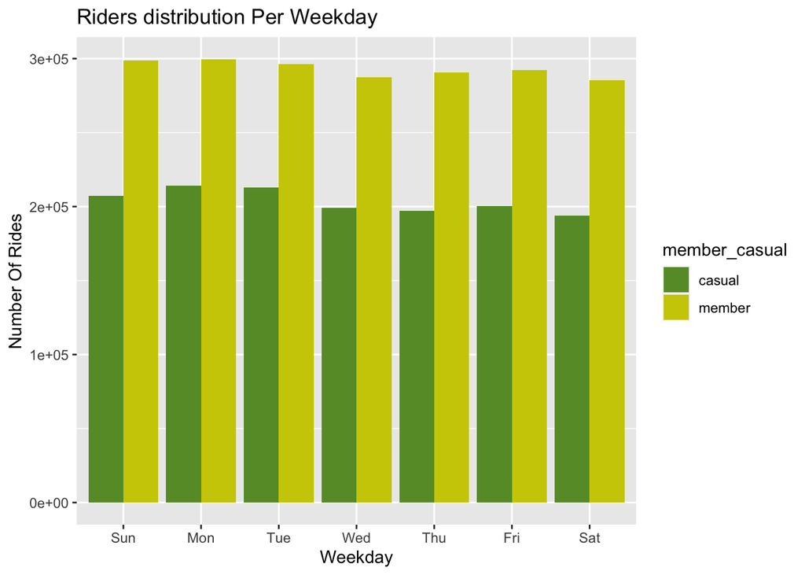

```r
df_trips_3 %>%
  mutate(weekday = wday(started_at, label = TRUE)) %>%
  group_by(member_casual, weekday) %>%
  summarise(number_of_rides = n()
            ,average_duration = mean(ride_length_seconds)) %>%
  arrange(member_casual, weekday)  %>%
  ggplot(aes(x = weekday, y = number_of_rides, fill = member_casual)) +
  scale_fill_manual(values = c("casual" = "#669933", "member" = "#CCCC00"))+
  geom_col(position = "dodge") +
  labs(x="Weekday", y="Number Of Rides",
       title= "Riders distribution Per Weekday")
```

## Let’s create a visualization for average duration.

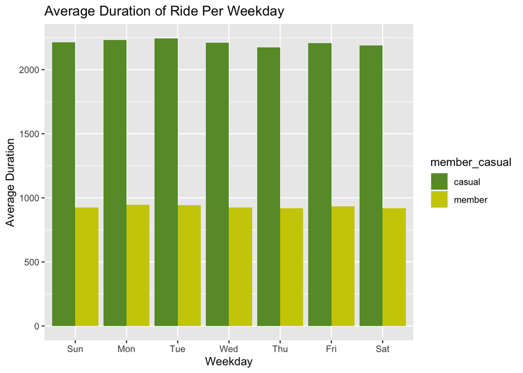

```r
  df_trips_3 %>%
    mutate(weekday = wday(started_at, label = TRUE)) %>%
    group_by(member_casual, weekday) %>%
    summarise(number_of_rides = n()
              ,average_duration = mean(ride_length_seconds)) %>%
    arrange(member_casual, weekday)  %>%
    ggplot(aes(x = weekday, y = average_duration, fill = member_casual)) +
    scale_fill_manual(values = c("casual" = "#669933", "member" = "#CCCC00"))+
    geom_col(position = "dodge") +
    labs(x="Weekday", y="Average Duration", title= "Average Duration of Ride Per Weekday")
```

## Members vs casual riders by their total rides taken.

```r
  df_trips_3 %>%
    group_by(member_casual) %>%
    summarise(ride_count = length(ride_id),
              ride_percentage = (length(ride_id) / nrow(df_trips_3)) * 100)
```

```
## # A tibble: 2 × 3
##   member_casual ride_count ride_percentage
##   <chr>              <int>           <dbl>
## 1 casual           1424941            41.0
## 2 member           2049543            59.0
```

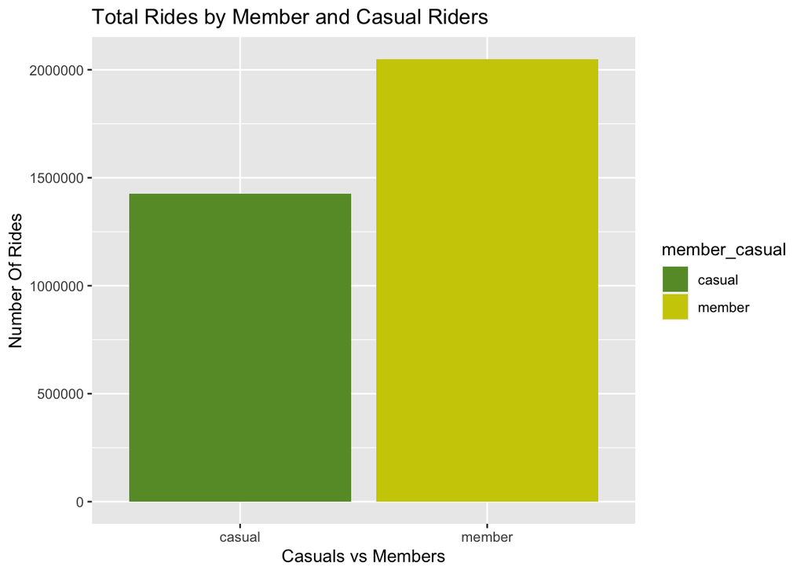

```r
  ggplot(df_trips_3, aes(x = member_casual, fill=member_casual)) +
    geom_bar() +
    scale_fill_manual(values = c("casual" = "#669933", "member" = "#CCCC00"))+
    labs(x="Casuals vs Members", y="Number Of Rides",
         title= "Total Rides by Member and Casual Riders")
```

## Fix the order of the month, and visualize the total rides of members and casual riders per month.

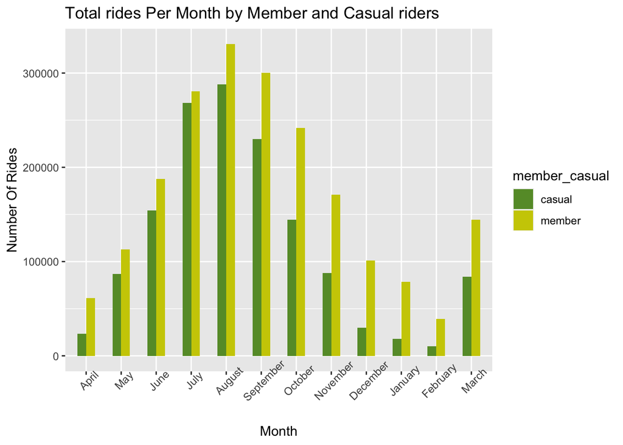

```r
 df_trips_3$month <- ordered(df_trips_3$month,
                                  levels=c( "April", "May", "June", "July",
                                           "August", "September", "October",
                                           "November", "December", "January",
                                           "February", "March"))


  df_trips_3%>%
    group_by(member_casual, month) %>%
    summarise(number_of_rides = n(),.groups="drop") %>%
    arrange(member_casual, month) %>%
    ggplot(aes(x = month, y = number_of_rides, fill = member_casual)) +
    scale_fill_manual(values = c("casual" = "#669933", "member" = "#CCCC00"))+
    labs(title ="Total rides Per Month by Member and Casual riders",
         x = "Month", y= "Number Of Rides")+
    theme(axis.text.x = element_text(angle = 45)) +
    geom_col(width=0.5, position = position_dodge(width=0.5)) +
    scale_y_continuous(labels = function(x) format(x, scientific = FALSE))
```

## Total rides per ride-able types by member and casual riders.

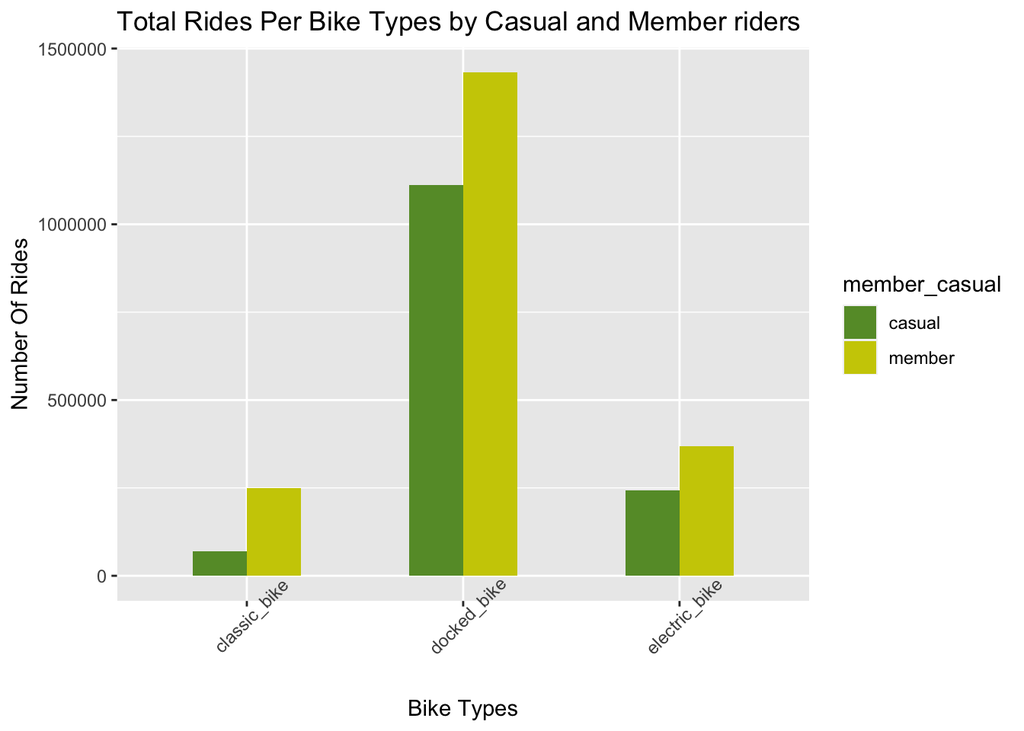

```r
  df_trips_3%>%
    group_by(member_casual, rideable_type) %>%
    summarise(number_of_rides = n(),.groups="drop") %>%
    arrange(member_casual, rideable_type) %>%
    ggplot(aes(x = rideable_type, y = number_of_rides, fill = member_casual)) +
    scale_fill_manual(values = c("casual" = "#669933", "member" = "#CCCC00"))+
    labs(title ="Total Rides Per Bike Types by Casual and Member riders",
         x = "Bike Types", y= "Number Of Rides")+
    theme(axis.text.x = element_text(angle = 45)) +
    geom_col(width=0.5, position = position_dodge(width=0.5)) +
    scale_y_continuous(labels = function(x) format(x, scientific = FALSE))
```

### The number of rides taken by both riders based on the type of bikes reflects that docked bikes was mostly used throughout the year and this could be because docked bikes have security features, and this made it preferable. The chart also shows that electric bikes were mostly used by riders than the classic bike type, this could mean that people would rather use electric bikes because it’s probably less stressful and consumes less gas.

## Bike types used by riders based on the time of the year.

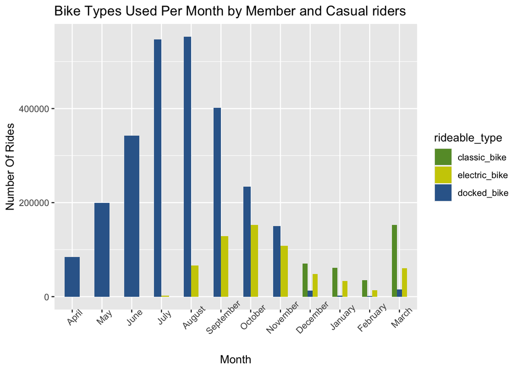

```r
  df_trips_3%>%
    group_by(rideable_type, month) %>%
    summarise(number_of_rides = n(),.groups="drop") %>%
    arrange(rideable_type, month) %>%
    ggplot(aes(x = month, y = number_of_rides, fill = rideable_type)) +
    scale_fill_manual(values = c("classic_bike" = "#669933", "electric_bike" = "#CCCC00", "docked_bike" = "#336699"))+
    labs(title ="Bike Types Used Per Month by Member and Casual riders",
         x = "Month", y= "Number Of Rides")+
    theme(axis.text.x = element_text(angle = 45)) +
    geom_col(width=0.5, position = position_dodge(width=0.5)) +
    scale_y_continuous(labels = function(x) format(x, scientific = FALSE))
```

### This chart shows how bikes were used during the seasons of the year. Docked bikes were mostly used in the summer and barely used in the winter. In autumn, more electric bikes were used, while classic bikes were mostly used in the winter.

# Findings and Recommendations

1. On a average, members take more rides than casual riders, they have the biggest portion of the total rides; so, to compel casual riders to opt in for membership subscription, discounts could be given out to casual riders that’d like to switch to become members, followed by a flexible payment plan
2. Riders tend to use more docked bikes; hence, funds should be directed to acquiring more docked bikes and maybe implementing the catchy features on docked bikes to the others so that riders can have alternatives if docked bikes run out of rentage.
3. Marketing strategies like campaigns can be done via advertisement to state the benefits of membership, this will compel riders to opt into the membership subscription.

# Study Limitation

More variables like gender, income, house location, family status etc., would have explained more to determine the growth and help to build more insights on the cyclistic bike share company to maximize profit.